# The Detective’s Toolkit

Finding Hidden Causes with Instrumental Variables

Jonathan Seward

Spring 2026

# The Problem: Correlation Lies

Why Naive Associations Mislead

## A Medical Mystery

**The Puzzle**

Hospitals that spend more money have **worse** patient outcomes.

Should we cut hospital budgets to improve health?

**Obviously not.** But this is exactly what the raw data suggests.

What’s going on here?

> “The most important things are often invisible to simple statistics.”

## Why Correlations Deceive Us

Consider this scenario from hospital data:

**Show R Code**

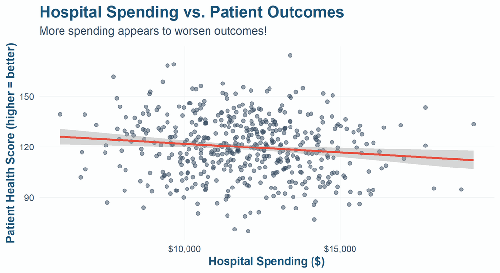

Figure 1: The naive correlation suggests spending hurts patients

```r
ggplot(hospital_data, aes(x = spending, y = outcome_score)) +
  geom_point(alpha = 0.5, color = slate_gray, size = 2.5) +
  geom_smooth(method = "lm", se = TRUE, color = accent_coral, linewidth = 1.5) +
  labs(
    title = "Hospital Spending vs. Patient Outcomes",
    subtitle = "More spending appears to worsen outcomes!",
    x = "Hospital Spending ($)",
    y = "Patient Health Score (higher = better)"
  ) +
  scale_x_continuous(labels = dollar_format()) +
  theme_health_econ(base_size = 18)
```

## The Hidden Variable: Severity

### What We See

- Spending goes up
- Outcomes go down
- Correlation: **negative**

### What We Miss

- **Sicker patients** need more care
- **Sicker patients** have worse outcomes
- Severity drives *both* variables

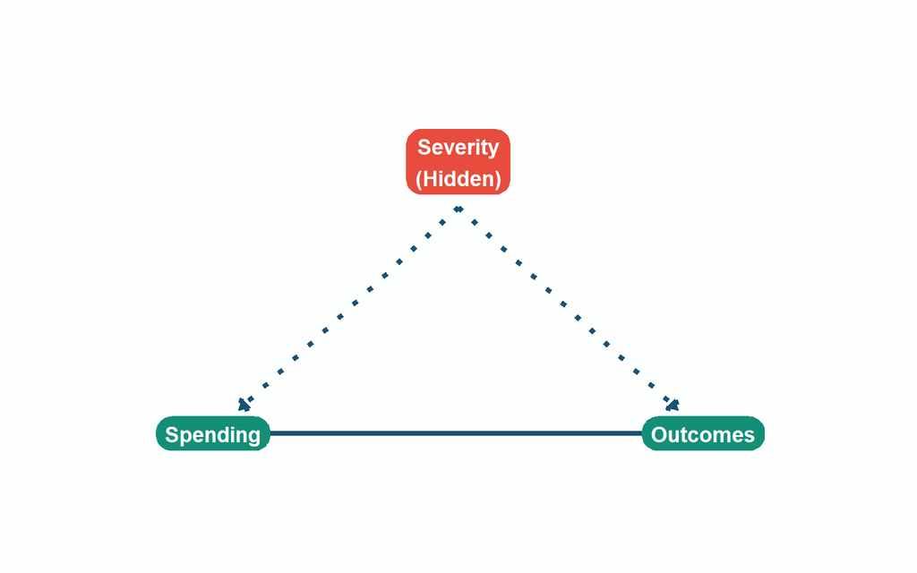

Figure 2: The hidden confounder creates a spurious correlation

## Revealing the Truth

When we account for patient severity, the picture changes completely:

**Show R Code**

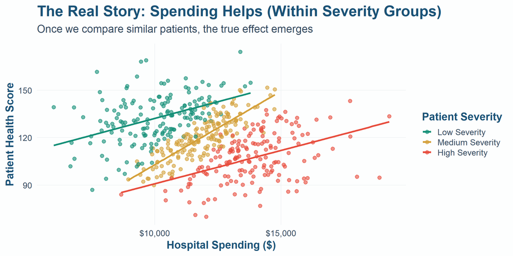

Figure 3: Within severity groups, spending actually HELPS

```r
hospital_data %>%
  mutate(severity_group = cut(severity,
                              breaks = quantile(severity, c(0, 0.33, 0.67, 1)),
                              labels = c("Low Severity", "Medium Severity", "High Severity"),
                              include.lowest = TRUE)) %>%
  ggplot(aes(x = spending, y = outcome_score, color = severity_group)) +
  geom_point(alpha = 0.6, size = 2.5) +
  geom_smooth(method = "lm", se = FALSE, linewidth = 1.5) +
  scale_color_manual(values = c(secondary_teal, warm_gold, accent_coral),
                     name = "Patient Severity") +
  scale_x_continuous(labels = dollar_format()) +
  labs(
    title = "The Real Story: Spending Helps (Within Severity Groups)",
    subtitle = "Once we compare similar patients, the true effect emerges",
    x = "Hospital Spending ($)",
    y = "Patient Health Score"
  ) +
  theme_health_econ(base_size = 18) +
  theme(legend.position = "right")
```

## The Core Problem

**Endogeneity**

When the thing we’re studying (spending) is connected to hidden factors (severity) that also affect our outcome.

**Three Sources of Endogeneity:**

1. **Omitted Variables** - We can’t measure everything that matters
2. **Reverse Causality** - Maybe outcomes affect spending?
3. **Measurement Error** - Our data is imperfect

**The Big Question:** How do we find causal effects when we can’t see everything?

## From Correlation to Instruments

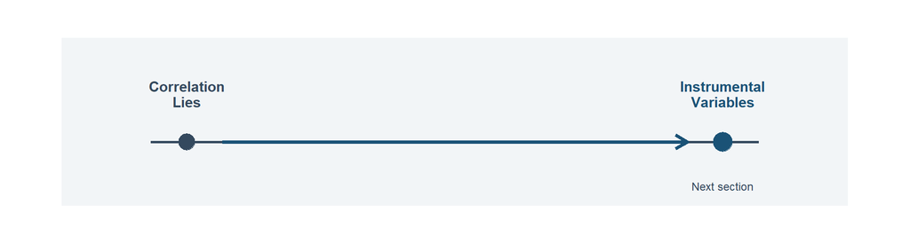

Figure 4

# Enter: Instrumental Variables

A Strategy for Hidden Confounding

## The Detective’s Insight

**The Key Idea**

Find something that affects *treatment* but has **no other connection** to *outcomes*.

Think of it like this:

- You want to know if **coffee** improves **productivity**
- But motivated people drink more coffee AND are more productive
- What if coffee prices varied randomly across cities?
- Price changes who drinks coffee, but doesn’t directly affect productivity

**Price is an “instrument”** - it creates *as-if-random* variation in coffee drinking.

## What Makes a Good Instrument?

An instrument $Z$ must satisfy two conditions:

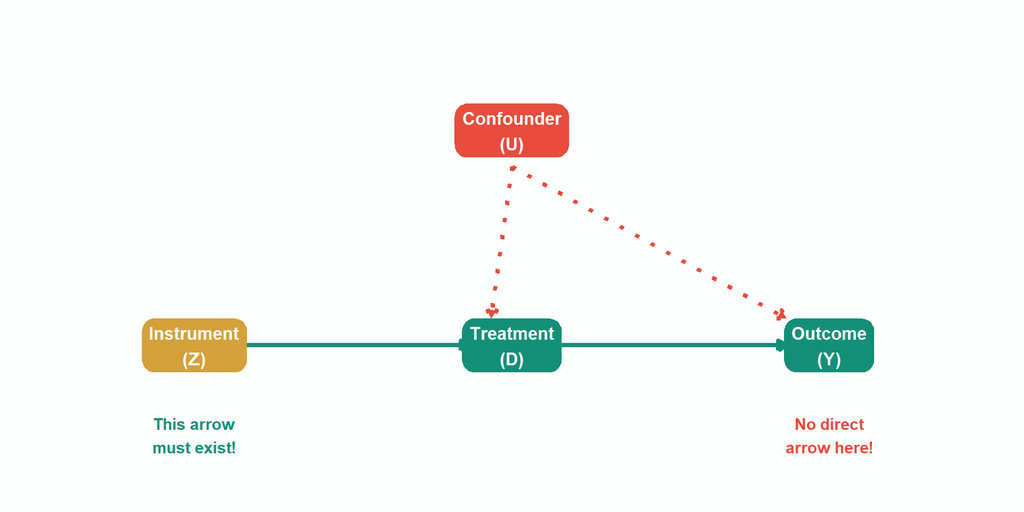

Figure 5: The instrument affects outcomes ONLY through the treatment

## Requirement #1: Relevance (First Stage)

The instrument must actually affect treatment:

$$\text{Cov}(Z, D) \neq 0$$

**Quick Stats Refresher**

**Covariance** measures how two variables move together. If $Z$ and $D$ have positive covariance, when $Z$ goes up, $D$ tends to go up too.

**Good news:** This is **testable**! We can check with data whether the instrument actually moves the treatment.

## Requirement #2: Exclusion Restriction

The instrument affects outcomes **only through** treatment: $Z \rightarrow Y$ only via $D$

There must be **no direct path** from $Z$ to $Y$ that bypasses treatment.

**The Hard Part**

This is **not testable**. We must argue it convincingly with theory and institutional knowledge.

**Graduate Students: Formal Statement**

Exclusion states $Y_i(d, z) = Y_i(d, z') \; \forall z, z'$. Potential outcomes depend only on treatment, not instrument value.

## A Classic Example: Family Size and Work

**Question:** Does having more children cause mothers to work less?

**Problem:** Women who prefer staying home have more kids AND work less

**Solution (Angrist & Evans, 1998):**

- Parents often want at least one child of each sex
- First two same-sex → more likely to have third
- Sex of children is **random**!

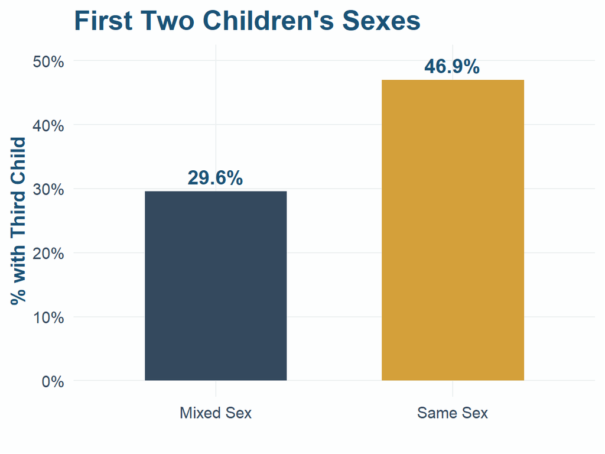

Figure 6: Same-sex children predict larger families

## Why This Works: The Grandma Test

**The Grandma Principle**

A good instrument seems puzzling to someone who doesn’t know the research question.

**Imagine telling your grandmother:**

> “The sex of a woman’s first two children predicts whether she works.”

Her reaction: “That makes no sense! Why would that matter?”

**Exactly.** It only makes sense *through* family size:

Same-sex kids → More kids → Less work

If the correlation made sense on its own, the instrument might not be valid.

## From Idea to Estimation

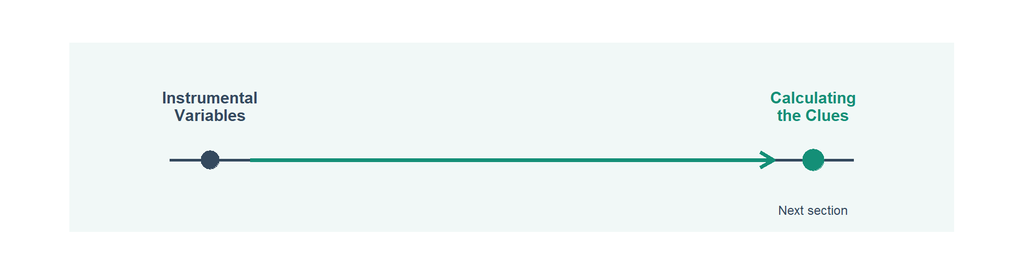

Figure 7

# The Detective’s Method: Calculating the Clues

From Intuition to the Wald Estimator

## From Intuition to Calculation

Now that we understand *what* makes a good instrument, let’s see *how* to use it.

The detective has gathered the clues — now it’s time to solve the case.

## The Wald Estimator: Ratios Tell the Story

The simplest IV estimator is just a ratio:

$$\hat{\delta}_{IV} = \frac{\text{Change in Outcome when } Z \text{ changes}}{\text{Change in Treatment when } Z \text{ changes}}$$

Or in statistics notation:

$$\hat{\delta}_{IV} = \frac{\text{Cov}(Y, Z)}{\text{Cov}(D, Z)} = \frac{\text{Reduced Form}}{\text{First Stage}}$$

- **Reduced Form**: Effect of instrument on outcome (numerator)
- **First Stage**: Effect of instrument on treatment (denominator)

**Graduate Students: Deriving the Wald Estimator**

Starting with $Y = \alpha + \delta D + \gamma A + \nu$: $\text{Cov}(Y, Z) = \delta \cdot \text{Cov}(D, Z) + \gamma \cdot \text{Cov}(A, Z) + \text{Cov}(\nu, Z)$. If exclusion holds, the last two terms are zero, giving $\hat{\delta}_{Wald} = \text{Cov}(Y, Z) / \text{Cov}(D, Z)$.

## Visual Intuition for Wald

**Show R Code**

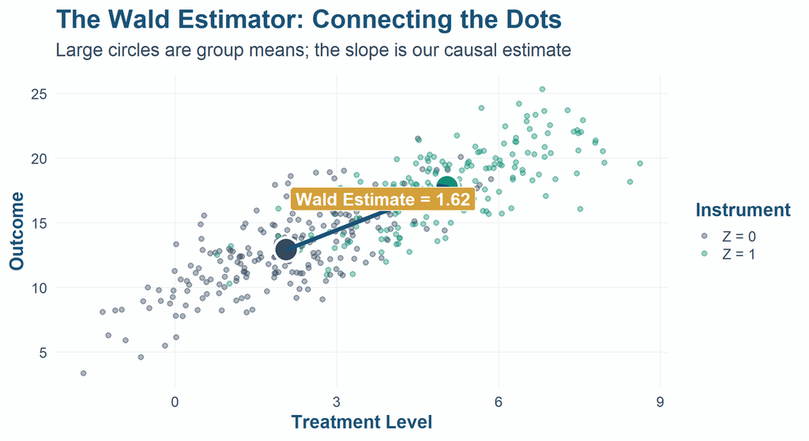

Figure 8: The Wald estimator is the slope connecting group means

```r
# Generate IV data
set.seed(123)
n <- 400
iv_demo <- tibble(
  instrument = rbinom(n, 1, 0.5),
  treatment = 2 + 3 * instrument + rnorm(n, 0, 1.5),
  outcome = 10 + 1.5 * treatment + rnorm(n, 0, 2)
)

# Calculate group means
group_means <- iv_demo %>%
  group_by(instrument) %>%
  summarize(mean_treat = mean(treatment), mean_out = mean(outcome), .groups = "drop")

# Calculate Wald
delta_treat <- diff(group_means$mean_treat)
delta_out <- diff(group_means$mean_out)
wald_est <- delta_out / delta_treat

ggplot(iv_demo, aes(x = treatment, y = outcome)) +
  geom_point(aes(color = factor(instrument)), alpha = 0.4, size = 2) +
  geom_point(data = group_means, aes(x = mean_treat, y = mean_out,
                                      fill = factor(instrument)),
             size = 10, shape = 21, color = "white", stroke = 2) +
  geom_segment(data = group_means,
               aes(x = mean_treat[1], y = mean_out[1],
                   xend = mean_treat[2], yend = mean_out[2]),
               linewidth = 2, color = primary_blue,
               arrow = arrow(length = unit(0.3, "cm"), type = "closed")) +
  annotate("label", x = mean(group_means$mean_treat) + 0.3,
           y = mean(group_means$mean_out) + 1.5,
           label = paste0("Wald Estimate = ", round(wald_est, 2)),
           size = 6, fill = warm_gold, color = "white", fontface = "bold") +
  scale_color_manual(values = c(slate_gray, secondary_teal),
                     labels = c("Z = 0", "Z = 1"), name = "Instrument") +
  scale_fill_manual(values = c(slate_gray, secondary_teal), guide = "none") +
  labs(title = "The Wald Estimator: Connecting the Dots",
       subtitle = "Large circles are group means; the slope is our causal estimate",
       x = "Treatment Level", y = "Outcome") +
  theme_health_econ(base_size = 18) +
  theme(legend.position = "right")
```

## Two-Stage Least Squares (2SLS)

### Stage 1: Predict Treatment

$$\hat{D} = \hat{\pi}_0 + \hat{\pi}_1 Z$$

Creates “cleaned” treatment reflecting only instrument-driven variation.

### Stage 2: Use Predictions

$$Y = \hat{\alpha} + \hat{\delta} \cdot \hat{D}$$

The coefficient $\hat{\delta}$ is our causal estimate!

**Why This Works**

$\hat{D}$ only varies because of $Z$, removing confounder variation.

**Graduate Students: 2SLS Standard Errors**

Don’t run two regressions manually — $\hat{D}$ is estimated, not observed! Use `ivreg()` in R or `ivregress` in Stata for proper SEs.

## From Estimation to Diagnostics

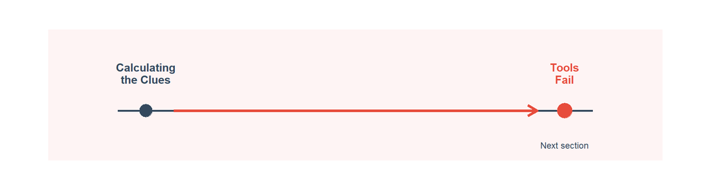

Figure 9

# When the Detective’s Tools Fail

Weak Instruments and Exclusion Violations

## Danger #1: Weak Instruments

**Warning**

If your first-stage F-statistic is below 10, your instrument is **weak**.

**Show R Code**

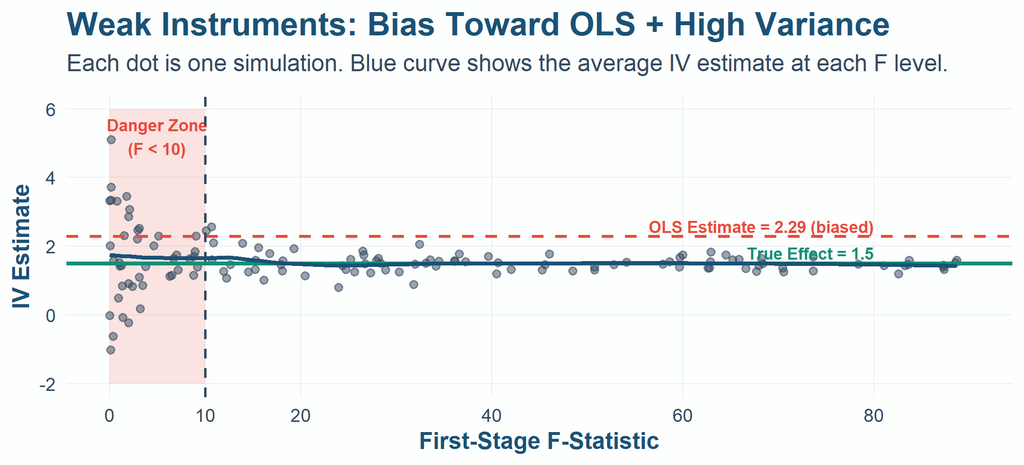

Figure 10: As F-statistic drops, IV estimates become biased toward OLS and more variable

```r
# Simulate IV with varying instrument strength
simulate_iv <- function(n = 150, strength = 1.0) {
  tibble(
    u = rnorm(n),
    z = rnorm(n),
    # Treatment depends on confounder u and instrument z
    d = 0.8 * u + strength * z + rnorm(n, 0, 0.3),
    # True effect of d is 1.5; confounder u biases OLS upward
    y = 2 + 1.5 * d + 1.2 * u + rnorm(n, 0, 0.5)
  )
}

set.seed(456)
n_sims <- 300

# Simulate across many strength values to get continuous F distribution
iv_results <- map_dfr(seq(0.02, 1.5, length.out = 15), function(str) {
  map_dfr(1:20, function(i) {
    dat <- simulate_iv(n = 150, strength = str)
    fs <- lm(d ~ z, data = dat)
    iv <- ivreg(y ~ d | z, data = dat)
    ols <- lm(y ~ d, data = dat)
    tibble(
      strength = str,
      iv_est = coef(iv)["d"],
      ols_est = coef(ols)["d"],
      f_stat = summary(fs)$fstatistic[1]
    )
  })
})

# Calculate OLS bias for reference
ols_biased <- mean(iv_results$ols_est)

ggplot(iv_results, aes(x = f_stat, y = iv_est)) +
  # Shade the "danger zone" where F < 10
  annotate("rect", xmin = 0, xmax = 10, ymin = -2, ymax = 6,
           fill = accent_coral, alpha = 0.15) +
  annotate("text", x = 5, y = 5.2, label = "Danger Zone\n(F < 10)",
           color = accent_coral, fontface = "bold", size = 4.5) +
  # Add points

  geom_point(alpha = 0.5, size = 2.5, color = slate_gray) +
  # True effect line
  geom_hline(yintercept = 1.5, linetype = "solid", color = secondary_teal, linewidth = 1.5) +
  annotate("text", x = 80, y = 1.5 + 0.3, label = "True Effect = 1.5",
           color = secondary_teal, fontface = "bold", size = 4.5, hjust = 1) +
  # OLS (biased) line
  geom_hline(yintercept = ols_biased, linetype = "dashed", color = accent_coral, linewidth = 1.2) +
  annotate("text", x = 80, y = ols_biased + 0.3, label = paste0("OLS Estimate = ", round(ols_biased, 2), " (biased)"),
           color = accent_coral, fontface = "bold", size = 4.5, hjust = 1) +
  # F = 10 threshold
  geom_vline(xintercept = 10, linetype = "dashed", color = slate_gray, linewidth = 1) +
  # Smooth trend to show bias pattern
  geom_smooth(method = "loess", se = FALSE, color = primary_blue, linewidth = 1.5, span = 0.5) +
  scale_x_continuous(limits = c(0, 90), breaks = c(0, 10, 20, 40, 60, 80)) +
  scale_y_continuous(limits = c(-2, 6)) +
  labs(
    title = "Weak Instruments: Bias Toward OLS + High Variance",
    subtitle = "Each dot is one simulation. Blue curve shows the average IV estimate at each F level.",
    x = "First-Stage F-Statistic",
    y = "IV Estimate"
  ) +
  theme_health_econ(base_size = 18)
```

## Danger #2: Exclusion Violations

The exclusion restriction is **untestable**. You must argue it convincingly.

**Good Arguments:** Mechanism knowledge, literally random, no alternative pathways

**Red Flags:** “Seems unrelated”, complex chains, multiple pathways

Table 1

| Instrument | Potential Violation |
| --- | --- |
| Lottery (draft) | Affects education choices |
| Birth quarter | Correlates with family SES |
| Distance to college | Correlates with labor markets |
| Weather | Affects mood directly |

## The Five Assumptions

Table 2

| # | Assumption | Plain English | Testable |
| --- | --- | --- | --- |
| 1 | SUTVA | No interference between units | Sometimes |
| 2 | Independence | Instrument is as-good-as random | Partially |
| 3 | Exclusion | Instrument affects Y only through D | No |
| 4 | Relevance | Instrument actually changes D | Yes! |
| 5 | Monotonicity | Instrument moves everyone same direction | Rarely |

**Key insight:** Only *relevance* is fully testable. The others require theory.

**Graduate Students: Formal Statements**

1. **SUTVA**: $Y_i = Y_i(D_i)$ | 2. **Independence**: $(Y^0, Y^1, D^0, D^1) \perp\!\!\!\perp Z$ | 3. **Exclusion**: $Y_i(d, z) = Y_i(d, z')$ | 4. **Relevance**: $E[D^1 - D^0] \neq 0$ | 5. **Monotonicity**: $D^1 \geq D^0 \; \forall i$

## From Failure Modes to LATE

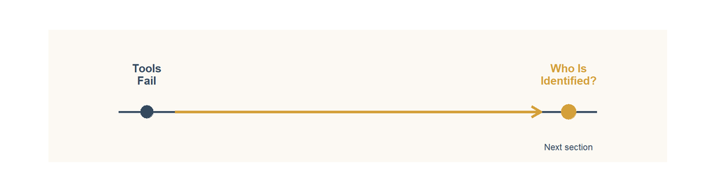

Figure 11

# Who Did the Detective Actually Identify?

Interpreting the Complier Population

## The LATE Framework

**Critical Insight**

IV estimates the effect for **compliers** only — not everyone!

Table 3

| Type | Definition | IV Applies? |
| --- | --- | --- |
| Always Takers | Take treatment regardless of Z | No |
| Never Takers | Never take treatment regardless of Z | No |
| Compliers | Take treatment only when Z is 'on' | Yes! |
| Defiers | Do the opposite of Z | Violates monotonicity |

## Visualizing LATE

**Show R Code**

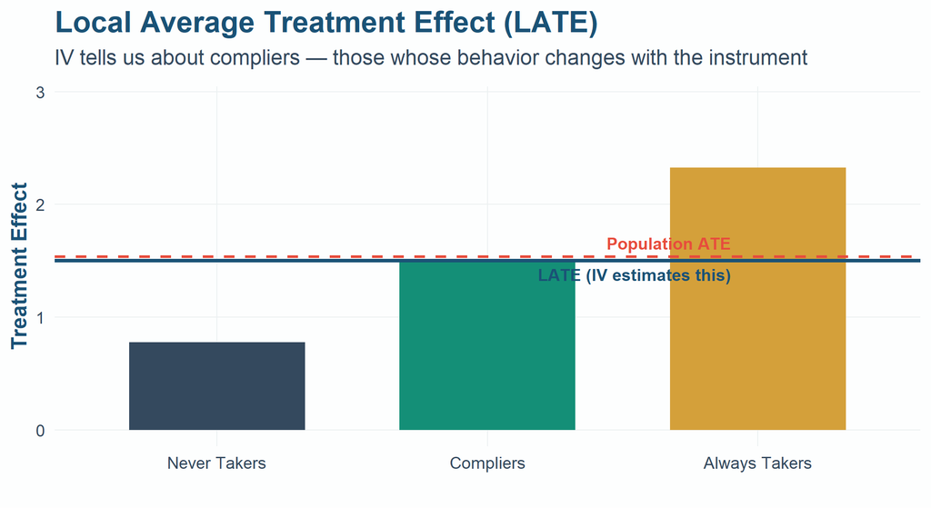

Figure 12: IV estimates LATE: the effect for compliers only

```r
set.seed(789)
late_data <- tibble(
  type = rep(c("Never Takers", "Compliers", "Always Takers"), each = 200),
  effect = c(rnorm(200, 0.8, 0.4), rnorm(200, 1.5, 0.4), rnorm(200, 2.3, 0.4))
)

late_summary <- late_data %>%
  group_by(type) %>%
  summarize(mean_eff = mean(effect), .groups = "drop") %>%
  mutate(type = factor(type, levels = c("Never Takers", "Compliers", "Always Takers")))

pop_ate <- mean(late_data$effect)

ggplot(late_summary, aes(x = type, y = mean_eff, fill = type)) +
  geom_col(width = 0.65, show.legend = FALSE) +
  geom_hline(yintercept = pop_ate, linetype = "dashed", color = accent_coral, linewidth = 1.2) +
  geom_hline(yintercept = 1.5, linetype = "solid", color = primary_blue, linewidth = 1.5) +
  annotate("text", x = 2.9, y = pop_ate + 0.12, label = "Population ATE",
           color = accent_coral, fontface = "bold", size = 5, hjust = 1) +
  annotate("text", x = 2.9, y = 1.5 - 0.12, label = "LATE (IV estimates this)",
           color = primary_blue, fontface = "bold", size = 5, hjust = 1) +
  annotate("segment", x = 1.7, xend = 2.3, y = 0.35, yend = 0.35,
           arrow = arrow(length = unit(0.2, "cm"), ends = "both"),
           color = secondary_teal, linewidth = 1.5) +
  annotate("text", x = 2, y = 0.2, label = "IV focuses here",
           color = secondary_teal, fontface = "bold", size = 5) +
  scale_fill_manual(values = c(slate_gray, secondary_teal, warm_gold)) +
  labs(title = "Local Average Treatment Effect (LATE)",
       subtitle = "IV tells us about compliers — those whose behavior changes with the instrument",
       x = "", y = "Treatment Effect") +
  theme_health_econ(base_size = 18) +
  coord_cartesian(ylim = c(0, 2.9))
```

## LATE: Blessing or Curse?

### The Good News

- LATE is a real causal effect
- For people whose behavior *can be changed*
- Often policy-relevant (marginal responders)

*Draft lottery*: effect for those who **would serve if drafted but wouldn’t otherwise** — exactly who a draft affects!

### The Caution

- LATE ≠ ATE
- May not generalize
- Different instruments → different LATEs

*Birth quarter IV*: effect for **minimum-age dropouts** — is that who we care about?

**Graduate Students: The LATE Theorem**

Under assumptions 1-5: $\delta_{IV} = E[Y^1 - Y^0 | D^1 > D^0]$ — the causal effect for compliers. Different instruments identify different complier populations.

## From Interpretation to Practice

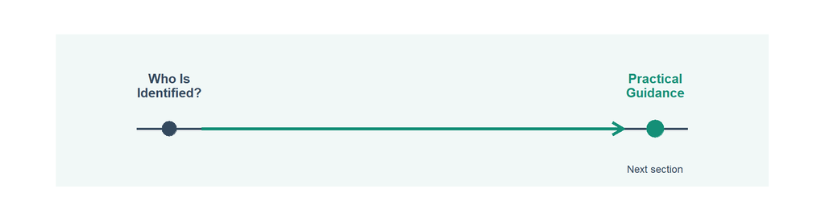

Figure 13

# The Detective’s Report: Practical Guidance

What to Report and How to Defend It

## What to Report in IV Studies

Table 4

| Analysis | What It Shows | Why Include |
| --- | --- | --- |
| Naive OLS | Baseline (biased) | Shows bias to fix |
| First Stage | Z → D effect | Proves relevance |
| Reduced Form | Z → Y effect | Interpretable causal |
| IV/2SLS | D → Y causal effect | Main result |
| F-statistic | Instrument strength | Weak IV diagnostic |

**Pro tip:** Always show the reduced form — it’s the causal effect of $Z$, easier to defend than IV.

## Summary: The IV Checklist

Before trusting an IV analysis, ask:

**Checklist**

1. **Is there a strong first stage?** (F > 10)
2. **Is the exclusion restriction plausible?** (No alternative pathways)
3. **Is independence credible?** (Instrument as-good-as random)
4. **Who are the compliers?** (Is LATE what we want?)
5. **Are the reduced form results sensible?** (Right direction?)

## Key Takeaways

### What We Learned

1. Correlation lies due to **confounders**
2. Instruments create **as-if-random** variation
3. IV = Reduced Form / First Stage
4. Only **relevance** is testable
5. IV estimates **LATE**, not ATE

### The Big Picture

IV = detective using **indirect evidence**:

- Can’t see the confounder
- Found something that moves D randomly
- Follow that thread to causation

> “A good instrument is a gift from nature.”

## Looking Ahead

**Coming Up**

- **Regression Discontinuity**: When rules create quasi-experiments
- **Difference-in-Differences**: Before-after comparisons done right
- **Applications**: How these tools solve real health economics puzzles

## Discussion Questions

1. **Hospital spending revisited:** What might be a valid instrument for hospital spending in studying patient outcomes?
2. **Your research:** Think of a causal question you’re interested in. What confounders might bias a naive analysis? Can you imagine an instrument?
3. **Critical thinking:** A study uses “distance to hospital” as an instrument for receiving treatment. What are potential threats to the exclusion restriction?

## References & Resources

**Key Papers:** Angrist & Krueger (2001) “IV and the Search for Identification” *JEP*; Angrist & Evans (1998) “Children and Parents’ Labor Supply” *AER*

**Textbooks:** Angrist & Pischke (2009) *Mostly Harmless Econometrics*; Cunningham (2021) [*Causal Inference: The Mixtape*](https://mixtape.scunning.com/)

**This Deck:** Companion R script (`iv_walkthrough.R`) available for hands-on practice

## From Practice to Appendix

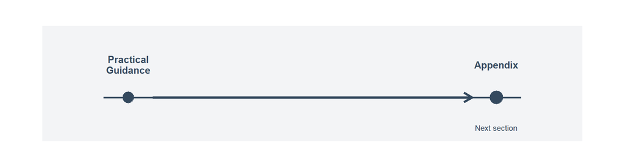

Figure 14

# Appendix: Advanced Topics

## Leniency Designs

A **leniency design** uses random assignment to decision-makers as an instrument.

**How It Works:**

1. Individuals move through a system (courts, hospitals, schools)
2. They’re **randomly assigned** to different decision-makers
3. Decision-makers differ in their **propensity to apply treatment**

**Examples:**

- **Judicial sentencing**: Judges randomly assigned; some are stricter (Kling 2006, Mueller-Smith 2015)
- **Foster care**: Caseworkers differ in removal decisions (Doyle 2007, 2008)
- **Radiologist diagnosis**: Random assignment to radiologists who differ in diagnosis rates (Chan et al. 2022)

**Key Challenge**

Leniency designs assume differences are due to **preferences**, not **skill**. If some judges are simply better at identifying who needs treatment, exclusion may fail.

## Sensitivity Analysis

Since exclusion is untestable, we analyze **sensitivity to violations**:

**Sources of Bias in IV:**

1. Direct effect of $Z$ on $Y$ for compliers
2. Direct effect of $Z$ on $Y$ for non-compliers, weighted by non-compliance probability

**Bias Formula:**

$$\text{plim } \hat{\delta}_{IV} = \delta + \frac{\text{Cov}(\eta, Z)}{\text{Cov}(D, Z)}$$

where $\eta$ is the composite error. Bias depends on:

- How strong the instrument is (denominator)
- How correlated the instrument is with unobservables (numerator)

**Practical Implication**

Strong instruments are more robust to small exclusion violations because the denominator is large.

## Monotonicity Violations

**What if there are defiers?**

Defiers do the **opposite** of what the instrument suggests: - Low draft number → *avoid* military (to spite the system) - High draft number → *volunteer* (perverse response)

**Consequences:**

$$\text{IV Bias} \propto \frac{\text{Pr(Defier)}}{\text{Pr(Complier)}} \times (ATE_{Defiers} - ATE_{Compliers})$$

If defiers and compliers have similar treatment effects, bias is small even with some defiers.

**Testing Monotonicity:**

- Cannot directly test (we don’t observe compliance types)
- Can check for **plausibility**: Does the instrument logically push everyone the same direction?
- Relaxations exist: “Average monotonicity” (Frandsen et al. 2019)

## Weak Instrument Inference

When $F < 10$, standard IV inference fails:

**Problems:**

- 2SLS is biased toward OLS
- Standard errors are too small
- t-tests have wrong size (reject true nulls too often)

**Solutions:**

1. **Anderson-Rubin (AR) test**: Valid inference regardless of instrument strength
2. **Conditional Likelihood Ratio (CLR)**: More powerful than AR
3. **LIML estimator**: Less biased than 2SLS with weak instruments
4. **tF adjustment**: Corrects critical values based on first-stage F

**Rule of Thumb Update**

The F > 10 rule (Stock & Yogo 2005) assumes you want 2SLS bias < 10% of OLS bias. For stricter standards, you need F > 20 or higher.

## Two-Sample IV

**When to use:** First stage and reduced form come from **different datasets**.

**Common scenarios:**

- Survey data (first stage) + admin data (reduced form)
- Historical instrument differs from outcome period
- Privacy prevents individual-level linking

**The Mechanics:**

1. First stage in Sample A: $\hat{\pi}_1$
2. Reduced form in Sample B: $\hat{\rho}$
3. IV estimate: $\hat{\delta}_{TSIV} = \hat{\rho} / \hat{\pi}_1$

**Warning**

Both samples must be from the **same population** — different complier populations break identification.

**SEs:** Use Inoue & Solon (2010) or bootstrap to account for two-stage uncertainty.

## 2SLS vs. LIML

Table 5

| Property | 2SLS | LIML |
| --- | --- | --- |
| Bias | Toward OLS | ≈ Median-unbiased |
| Weak IV | Poor | Better |
| Many IVs | Overfits | Robust |
| Speed | Fast | Slower |

**Prefer LIML when:**

- F < 20 (weak instrument)
- Many instruments
- Robustness check needed

**2SLS is fine when:**

- F > 20 (strong first stage)
- Single instrument
- Simplicity matters

**Tip**

Report **both**. If they differ, you have a weak instrument problem.

## Health Economics Application: Chan et al. (2022)

**Research Question:** How much diagnostic variation is due to physician **skill** vs. **preferences**?

**Setting:** VA radiologists diagnosing pneumonia from chest X-rays

**Design:** Patients quasi-randomly assigned to radiologists who differ in diagnosis rates

**Key Finding:** ~39% of diagnostic variation is due to **skill differences**

**Implications for IV:**

- Traditional leniency designs assume all variation is preferences
- If skill varies, **exclusion restriction may fail**
- Skilled radiologists affect outcomes through better diagnosis accuracy, not just diagnosis rates

**Methodological Contribution**

The paper develops partial identification bounds when skill and preferences cannot be separated — a more honest approach when exclusion is questionable.